# 3. Pre-Processing using caret

Russ Conte

4/30/2022

`caret` includes several functions to pre-process the predictor data. It assumes that all of the data are numeric (i.e. factors have been converted to dummy variables via `model.matrix`, `dummyVars`, or other means.)

### 3.1 Creating Dummy Variables

The function `dummuVars` can be used to generate a complete (less than full rank parameterized) set of dummy variables from one or more factors. The function takes a formula and a data set and outputs an object that can be used to create the dummy variables using the predict method.

For example, the `etitanic` data set in the `earth` package includes two factors: `pclass` (passenger class, with levels 1st, 2nd, and 3rd) and `sex` (with levels female, male).

Let’s load all the packages in two lines of code:

```r
Packages = c("AppliedPredictiveModeling", "caret", "tidyverse", "e1071", "earth")
lapply(Packages, library, character.only = TRUE)
```

[output not shown]

[output cut: 37 more lines]

Using `dummyVars`:

```r
dummies <- dummyVars(survived~., data = etitanic)
head(predict(dummies, newdata = etitanic))
```

```
##   pclass.1st pclass.2nd pclass.3rd sex.female sex.male     age sibsp parch
## 1          1          0          0          1        0 29.0000     0     0
## 2          1          0          0          0        1  0.9167     1     2
## 3          1          0          0          1        0  2.0000     1     2
## 4          1          0          0          0        1 30.0000     1     2
## 5          1          0          0          1        0 25.0000     1     2
## 6          1          0          0          0        1 48.0000     0     0
```

The authors point out there is no intercept, and each factor has a dummy variable for each level. This may not be useful for some modeling situations, such as `lm`.

Same idea, using the diamonds data set from tidyverse

```r
dummies <- dummyVars(price~., data = diamonds)
head(predict(dummies, newdata = diamonds))
```

```
##   carat         cut.L      cut.Q         cut.C      cut^4    color.L
## 1  0.23  6.324555e-01  0.5345225  3.162278e-01  0.1195229 -0.3779645
## 2  0.21  3.162278e-01 -0.2672612 -6.324555e-01 -0.4780914 -0.3779645
## 3  0.23 -3.162278e-01 -0.2672612  6.324555e-01 -0.4780914 -0.3779645
## 4  0.29  3.162278e-01 -0.2672612 -6.324555e-01 -0.4780914  0.3779645
## 5  0.31 -3.162278e-01 -0.2672612  6.324555e-01 -0.4780914  0.5669467
## 6  0.24 -1.481950e-18 -0.5345225 -3.893692e-16  0.7171372  0.5669467
##         color.Q    color.C    color^4    color^5     color^6   clarity.L
## 1  8.914347e-17  0.4082483 -0.5640761  0.4364358 -0.19738551 -0.38575837
## 2  8.914347e-17  0.4082483 -0.5640761  0.4364358 -0.19738551 -0.23145502
## 3  8.914347e-17  0.4082483 -0.5640761  0.4364358 -0.19738551  0.07715167
## 4 -5.621884e-17 -0.4082483 -0.5640761 -0.4364358 -0.19738551 -0.07715167
## 5  5.455447e-01  0.4082483  0.2417469  0.1091089  0.03289758 -0.38575837
## 6  5.455447e-01  0.4082483  0.2417469  0.1091089  0.03289758  0.23145502
##     clarity.Q  clarity.C  clarity^4  clarity^5  clarity^6  clarity^7 depth
## 1  0.07715167  0.3077287 -0.5237849  0.4921546 -0.3077287  0.1194880  61.5
## 2 -0.23145502  0.4308202 -0.1208734 -0.3637664  0.5539117 -0.3584641  59.8
## 3 -0.38575837 -0.1846372  0.3626203  0.3209704 -0.3077287 -0.5974401  56.9
## 4 -0.38575837  0.1846372  0.3626203 -0.3209704 -0.3077287  0.5974401  62.4
## 5  0.07715167  0.3077287 -0.5237849  0.4921546 -0.3077287  0.1194880  63.3
## 6 -0.23145502 -0.4308202 -0.1208734  0.3637664  0.5539117  0.3584641  62.8
##   table    x    y    z
## 1    55 3.95 3.98 2.43
## 2    61 3.89 3.84 2.31
## 3    65 4.05 4.07 2.31
## 4    58 4.20 4.23 2.63
## 5    58 4.34 4.35 2.75
## 6    57 3.94 3.96 2.48
```

### 3.2 Zero and Near Zero Variance Predictors

In some situations, the data generating mechanism can create predictors that only have a single unique value (i.e. a “zero-variance predictor”). For many models (excluding tree-based models) this may cause the model to crash or the fit to be unstable.

In a similar way, predictors might have only a handful of unique values gthat occur with very low frequencies. An example is the mdrr data set, and the `nR11` descriptor (number of 11-membered rings):

```r
data(mdrr)
data.frame(table(mdrrDescr$nR11))
```

```
##   Var1 Freq
## 1    0  501
## 2    1    4
## 3    2   23
```

The concern here is that these predictors may become zero – variance predictors when the data are split into cross – validation/bootstrap sub – summaries or that a few samples may have an undo influence on the model. These “nearest – zero – variance”predictors may need to be identified and eliminated prior to modeling.

If the frequency ratio was greater than a pre-– specified threshold and the unique value percentage is less than a threshold, we might consider a predictor to be near zero variance.

We would not want to false the identify data that have low granurity but are evenly distributed, such a from a discreet uniform distribution. Using both criteria should not false detect such predictors.

Looking at the MDRR data, the `nearZeroVar` function can be used to identify near zero-variance variables (the `saveMetrics` argument can be used to show the details and usually defauls to `FALSE`)

```r
nzv <- nearZeroVar(mdrrDescr, saveMetrics = TRUE)
nzv[nzv$nzv,][1:10,]
```

```
##        freqRatio percentUnique zeroVar  nzv
## nTB     23.00000     0.3787879   FALSE TRUE
## nBR    131.00000     0.3787879   FALSE TRUE
## nI     527.00000     0.3787879   FALSE TRUE
## nR03   527.00000     0.3787879   FALSE TRUE
## nR08   527.00000     0.3787879   FALSE TRUE
## nR11    21.78261     0.5681818   FALSE TRUE
## nR12    57.66667     0.3787879   FALSE TRUE
## D.Dr03 527.00000     0.3787879   FALSE TRUE
## D.Dr07 123.50000     5.8712121   FALSE TRUE
## D.Dr08 527.00000     0.3787879   FALSE TRUE
```

```r
nzv <- nearZeroVar(mdrrDescr)
filteredDescr <- mdrrDescr[, -nzv]
dim(filteredDescr)
```

```
## [1] 528 297
```

Let’s use the tidyverse to find the predictors with the lowest variance:

```r
mdrrDescr %>%
  summarise(across(where(is.numeric), var)) %>%
  pivot_longer(everything()) %>%
  arrange(value)
```

```
## # A tibble: 342 × 2
##    name      value
##    <chr>     <dbl>
##  1 Xt    0.0000152
##  2 X5Av  0.0000495
##  3 X5A   0.0000636
##  4 X4Av  0.000103
##  5 X4A   0.000104
##  6 X3A   0.000135
##  7 X2A   0.000168
##  8 X1A   0.000168
##  9 PW5   0.000174
## 10 Me    0.000184
## # … with 332 more rows
```

By default `nearZeroVar` will return the positions of the variables that are flagged to be problems.

### 3.3 Identifying Correlated Predictors

```r
descrCor <- cor(filteredDescr)
highCorr <- sum(abs(descrCor[upper.tri(descrCor)]) > 0.999)
```

```r
descrCor <- cor(filteredDescr)
summary(descrCor[upper.tri(descrCor)])
```

```
##     Min.  1st Qu.   Median     Mean  3rd Qu.     Max.
## -0.99607 -0.05373  0.25006  0.26078  0.65527  1.00000
```

```r
highlyCorDescr <- findCorrelation(descrCor, cutoff = 0.75)
filteredDescr <- filteredDescr[,-highlyCorDescr]
descrCor2 <- cor(filteredDescr)
summary(descrCor2[upper.tri(descrCor2)])
```

```
##     Min.  1st Qu.   Median     Mean  3rd Qu.     Max.
## -0.70728 -0.05378  0.04418  0.06692  0.18858  0.74458
```

## Linear Dependencies

The function `findlinearCombos` uses the QR decomposition of a matrix to enumerate sets of linear combinations (if they exist). For example, consider the following metrics that could have been produced by less than full rank parameterization of a two-way experimental layout:

```r
ltfrDesign <- matrix(0, nrow=6, ncol=6)
ltfrDesign[,1] <- c(1, 1, 1, 1, 1, 1)
ltfrDesign[,2] <- c(1, 1, 1, 0, 0, 0)
ltfrDesign[,3] <- c(0, 0, 0, 1, 1, 1)
ltfrDesign[,4] <- c(1, 0, 0, 1, 0, 0)
ltfrDesign[,5] <- c(0, 1, 0, 0, 1, 0)
ltfrDesign[,6] <- c(0, 0, 1, 0, 0, 1)
```

Note that columns two and three add up to the first column. Similarly, columns four, five and six and up to the first column. `findlinearCombos` will return a list that enumerates these dependencies. for each linear combination, it will incrementally remove columns from the matrix and test to see if the dependencies have been resolved. `findlinearCombos` will also return of vector of column positions which can be removed to eliminate linear dependencies:

```r
comboInfo <- findLinearCombos(ltfrDesign)
comboInfo
```

```
## $linearCombos
## $linearCombos[[1]]
## [1] 3 1 2
##
## $linearCombos[[2]]
## [1] 6 1 4 5
##
##
## $remove
## [1] 3 6
```

```r
ltfrDesign[,-comboInfo$remove]
```

```
##      [,1] [,2] [,3] [,4]
## [1,]    1    1    1    0
## [2,]    1    1    0    1
## [3,]    1    1    0    0
## [4,]    1    0    1    0
## [5,]    1    0    0    1
## [6,]    1    0    0    0
```

These types of dependencies can arise when large numbers of binary chemical fingerprints are used to descrivbe the structure of a molecule.

## 3.5 The `preProcess` Function

The `preProcess` class can be used for many operations on predictors, including centering and scaling. The function `preProcess` estimates the required parameters for each operation and `predict.preProcess` is used to apply them to specific data sets. This function can also be interfaced when calling the `train` function.

Several types of techniques are described in the next few sections and then another example is used to demonstrate how multiple methods can be used. Note that, in all cases, the `preprocess` function estimates whatever it requires from a specific data set (e.g. the training set) and applies these transformations to *any* data set without recomputing the values.

## 3.6 Centering and Scaling

In the example below, the half of the MDRR data are used to estimate the location and scale of the predictors. The function `preProcess` doesn’t actually pre-process the data. `predict.preProcess` is used to pre-process this and other data sets.

```r
set.seed(96)
inTrain <- sample(seq(along = mdrrClass), length(mdrrClass)/2)

training <- filteredDescr[inTrain,]
test <- filteredDescr[-inTrain,]
trainMDRR <- mdrrClass[inTrain]
testMDRR <- mdrrClass[-inTrain]

preProcValues <- preProcess(training, method = c("center", "scale"))

trainTransformed <- predict(preProcValues, training)
testTransformed <- predict(preProcValues, test)
```

Let’s look at the resuls:

```r
mdrrClass[1:10]
```

```
##  [1] Active   Active   Inactive Active   Active   Active   Active   Active
##  [9] Active   Active
## Levels: Active Inactive
```

```r
inTrain[1:10]
```

[output not shown]

```r
training[1:10,]
```

```
##                        AMW   Mp   Ms nDB nAB nS nF nCL nR05 nR06 nR07 nR09 nR10
## METHOPROMAZINE        7.15 0.67 1.92   0  12  1  0   0    0    3    0    0    2
## TIPRENOLOL            6.72 0.64 2.17   0   6  1  0   0    0    1    0    0    0
## 4,8-DIPIPERIDYL-2,6-M 6.72 0.61 2.13   0  12  0  0   0    0    4    0    0    1
## RAZINODIL             7.66 0.63 2.41   3  15  0  0   0    0    4    0    0    1
## OXIPEROMIDE           7.03 0.66 2.08   1  12  0  0   0    1    3    0    1    0
## SPS1847               6.15 0.62 2.13   2  12  0  0   0    0    2    0    0    0
## S785781               6.82 0.64 2.07   1  12  0  0   0    0    4    0    0    1
## MESUPRINE             7.44 0.64 2.57   2  12  1  0   0    0    2    0    0    0
## R41300                8.26 0.67 2.23   2  14  0  0   2    2    3    0    0    0
## TUBULOZOLE            9.08 0.71 2.29   2  14  1  0   2    2    2    0    0    0
##                       nBnz  HNar    Xt       SPI Jhetm MAXDN MAXDP     TIE
## METHOPROMAZINE           2 1.941 0.000    68.906 2.266 0.753 1.915  86.993
## TIPRENOLOL               1 1.729 0.005   108.596 2.789 1.813 3.729  89.086
## 4,8-DIPIPERIDYL-2,6-M    0 2.045 0.000    39.166 2.096 1.486 3.246 371.919
## RAZINODIL                2 1.850 0.000 30213.500 1.938 2.308 6.573 472.020
## OXIPEROMIDE              2 2.113 0.000    12.247 1.416 1.660 5.322 222.721
## SPS1847                  2 1.835 0.000  3608.940 1.844 1.811 5.594 417.067
## S785781                  2 2.047 0.000    40.150 1.319 1.572 4.449 179.762
## MESUPRINE                2 1.733 0.000  5980.815 2.148 4.445 4.530 190.502
## R41300                   2 1.991 0.000   471.509 1.343 2.341 4.930 181.287
## TUBULOZOLE               2 1.951 0.000   349.170 1.745 2.291 4.540 146.459
##                         X5v   BLI   PW2   PW3   PW4  PJI2 BAC   Lop  IVDE  BIC2
## METHOPROMAZINE        2.929 1.047 0.570 0.326 0.182 1.000  17 1.517 1.891 0.640
## TIPRENOLOL            1.238 1.240 0.553 0.296 0.144 1.000  26 2.297 1.904 0.801
## 4,8-DIPIPERIDYL-2,6-M 3.087 1.008 0.553 0.321 0.190 0.857  17 1.205 1.673 0.643
## RAZINODIL             3.140 0.870 0.568 0.366 0.210 0.889 101 0.996 1.890 0.637
## OXIPEROMIDE           2.587 0.954 0.571 0.336 0.191 0.875   2 0.372 1.462 0.691
## SPS1847               2.588 1.098 0.547 0.332 0.174 1.000  53 0.913 1.753 0.608
## S785781               2.905 0.974 0.569 0.335 0.184 1.000   6 0.601 1.681 0.686
## MESUPRINE             2.107 1.118 0.587 0.313 0.149 1.000  55 1.135 2.110 0.784
## R41300                3.385 0.953 0.580 0.339 0.184 0.909  20 0.894 1.823 0.753
## TUBULOZOLE            3.291 1.009 0.575 0.328 0.181 1.000  21 1.133 1.867 0.830
##                        BIC5  VEA1     VRA1   piPC10    PCR T.O..O.     H3D
## METHOPROMAZINE        0.845 3.933  252.579 1367.438 11.641       0 141.324
## TIPRENOLOL            0.851 3.413  146.244   64.594  3.247       3 116.024
## 4,8-DIPIPERIDYL-2,6-M 0.785 4.428  398.527 2921.010 12.624      13 210.890
## RAZINODIL             0.799 4.383 1375.012 2015.805 25.834     384 259.690
## OXIPEROMIDE           0.861 3.776 1403.586  381.688  8.041       9 153.915
## SPS1847               0.724 5.159  393.010  124.625  4.175      48 324.518
```

[output cut: 11 more lines]

```
## S785781                78.163 0.368 0.961 0.736 0.979 22.9  4.364  30.415 0.145
## MESUPRINE              85.433 0.382 0.963 0.719 0.952 14.0  7.216  37.481 0.243
## R41300                130.774 0.372 0.974 0.715 0.957 13.1 14.378  90.414 0.174
## TUBULOZOLE            119.522 0.380 0.975 0.715 0.876  8.3 10.920  86.243 0.092
##                       G.N..N. G.N..O. G.O..Cl.
## METHOPROMAZINE           3.53    9.60     0.00
## TIPRENOLOL               0.00    5.72     0.00
## 4,8-DIPIPERIDYL-2,6-M   70.26   87.15     0.00
## RAZINODIL                9.31  190.31     0.00
## OXIPEROMIDE              7.59   19.57     0.00
## SPS1847                  3.52   38.00     0.00
## S785781                 18.56   49.05     0.00
## MESUPRINE                5.27   39.70     0.00
## R41300                  36.17  112.58    82.11
## TUBULOZOLE              14.62   60.81    60.89
```

```r
test[1:10,]
```

```
##                        AMW   Mp   Ms nDB nAB nS nF nCL nR05 nR06 nR07 nR09 nR10
## ACEPROMAZINE          7.26 0.68 2.06   1  13  1  0   0    0    3    0    0    2
## ACEPROMETAZINE        7.26 0.68 2.07   1  13  1  0   0    0    3    0    0    2
## MESORIDAZINE          7.44 0.69 1.95   1  12  2  0   0    0    4    0    0    2
## PERIMETAZINE          6.99 0.66 1.98   0  12  1  0   0    0    4    0    0    2
## PROPERICIAZINE        7.46 0.69 2.10   0  12  1  0   0    0    4    0    0    2
## DUOPERONE             8.30 0.69 2.59   1  19  1  4   0    0    5    0    0    2
## AHR06601              7.64 0.69 2.25   2  20  1  1   0    0    5    0    0    2
## PIPERACETAZINE        6.96 0.66 2.06   1  13  1  0   0    0    4    0    0    2
## PIPOTIAZINE-PALMITATE 6.38 0.63 2.02   3  12  2  0   0    0    4    0    0    2
## PROCHLORPERAZINE      7.63 0.69 1.87   0  12  1  0   1    0    4    0    0    2
##                       nBnz  HNar Xt       SPI Jhetm MAXDN MAXDP     TIE   X5v
## ACEPROMAZINE             2 1.890  0   173.971 2.309 1.551 4.755 130.429 3.026
## ACEPROMETAZINE           2 1.840  0   360.744 2.449 1.558 4.780 140.016 3.042
## MESORIDAZINE             2 2.000  0    74.148 1.928 2.180 5.011 102.348 4.498
## PERIMETAZINE             2 2.000  0    74.947 1.747 1.443 3.741 112.712 4.068
## PROPERICIAZINE           2 2.053  0    33.407 1.697 1.450 3.661 104.491 3.846
## DUOPERONE                3 1.955  0  1049.225 1.341 5.641 5.740 204.295 4.725
## AHR06601                 3 2.000  0   362.602 1.331 1.980 5.774 494.197 4.756
## PIPERACETAZINE           2 2.000  0   104.599 1.620 1.553 4.929 182.813 4.305
## PIPOTIAZINE-PALMITATE    2 1.915  0 16932.150 1.166 4.434 5.915 378.407 6.818
## PROCHLORPERAZINE         2 2.055  0    30.397 1.692 0.859 2.179  98.909 3.994
##                         BLI   PW2   PW3   PW4  PJI2 BAC   Lop  IVDE  BIC2  BIC5
## ACEPROMAZINE          1.046 0.580 0.324 0.175 1.000  24 1.532 1.897 0.664 0.843
## ACEPROMETAZINE        1.038 0.592 0.343 0.171 0.800  32 1.375 1.850 0.661 0.840
## MESORIDAZINE          1.213 0.584 0.347 0.185 0.833  11 0.721 1.826 0.690 0.888
## PERIMETAZINE          1.058 0.578 0.338 0.188 0.857  11 0.704 1.851 0.715 0.880
## PROPERICIAZINE        1.040 0.574 0.340 0.187 0.857   6 0.646 1.717 0.684 0.881
## DUOPERONE             0.967 0.595 0.341 0.175 1.000  27 0.683 1.882 0.676 0.867
## AHR06601              1.002 0.586 0.344 0.181 1.000  18 0.651 1.785 0.675 0.868
## PIPERACETAZINE        1.078 0.572 0.335 0.185 0.875  15 0.940 1.797 0.698 0.882
## PIPOTIAZINE-PALMITATE 1.243 0.561 0.316 0.154 1.000  61 2.696 1.677 0.548 0.799
## PROCHLORPERAZINE      1.087 0.579 0.335 0.187 1.000   5 0.477 1.811 0.623 0.851
##                        VEA1         VRA1   piPC10    PCR T.O..O.     H3D
## ACEPROMAZINE          4.013      263.951 1900.828 14.717       0 147.498
## ACEPROMETAZINE        4.108      176.537 1931.766 14.717       0 159.723
## MESORIDAZINE          4.187      312.720 1784.938 12.302       0 185.194
## PERIMETAZINE          4.126      483.021 1497.438 11.255      12 616.118
## PROPERICIAZINE        4.010      589.087 1714.000 13.258       0 168.342
## DUOPERONE             4.264     2893.059 1937.813 35.396       0 229.371
```

[output cut: 11 more lines]

```
## AHR06601              108.938 0.337 0.960 0.693 0.868  6.4  3.394  99.710 0.124
## PIPERACETAZINE         89.015 0.339 0.937 0.697 0.984  4.6 12.201  82.151 0.066
## PIPOTIAZINE-PALMITATE 158.527 0.372 0.984 0.747 0.954 27.5 27.522 142.342 0.393
## PROCHLORPERAZINE       81.268 0.341 0.929 0.711 0.925  3.9 11.943  71.188 0.141
##                       G.N..N. G.N..O. G.O..Cl.
## ACEPROMAZINE             3.53   11.53        0
## ACEPROMETAZINE           2.43   10.40        0
## MESORIDAZINE             3.51    9.28        0
## PERIMETAZINE             3.05   18.92        0
## PROPERICIAZINE          14.54   18.93        0
## DUOPERONE                3.51   10.70        0
## AHR06601                 3.53   21.76        0
## PIPERACETAZINE           3.52   24.13        0
## PIPOTIAZINE-PALMITATE   15.00   69.60        0
## PROCHLORPERAZINE        10.90    0.00        0
```

```r
trainMDRR[1:10]
```

```
##  [1] Active   Inactive Inactive Active   Inactive Active   Active   Inactive
##  [9] Active   Inactive
## Levels: Active Inactive
```

```r
testMDRR[1:10]
```

```
##  [1] Active   Active   Active   Active   Inactive Active   Active   Active
##  [9] Inactive Active
## Levels: Active Inactive
```

```r
preProcValues
```

```
## Created from 264 samples and 50 variables
##
## Pre-processing:
##   - centered (50)
##   - ignored (0)
##   - scaled (50)
```

```r
trainTransformed[1:10,]
```

```
##                                AMW         Mp          Ms        nDB        nAB
## METHOPROMAZINE         0.142028692  0.5531987 -0.90123494 -0.9086409 -0.2054619
## TIPRENOLOL            -0.400106382 -0.4204310  0.12946175 -0.9086409 -1.8166086
## 4,8-DIPIPERIDYL-2,6-M -0.400106382 -1.3940607 -0.03544972 -0.9086409 -0.2054619
## RAZINODIL              0.785026105 -0.7449742  1.11893057  2.7076586  0.6001115
## OXIPEROMIDE           -0.009264817  0.2286555 -0.24158906  0.2967923 -0.2054619
## SPS1847               -1.118750550 -1.0695175 -0.03544972  1.5022254 -0.2054619
## S785781               -0.274028458 -0.4204310 -0.28281692  0.2967923 -0.2054619
## MESUPRINE              0.507654672 -0.4204310  1.77857645  1.5022254 -0.2054619
## R41300                 1.541493650  0.5531987  0.37682896  1.5022254  0.3315870
## TUBULOZOLE             2.575332629  1.8513716  0.62419616  1.5022254  0.3315870
##                               nS         nF        nCL       nR05       nR06
## METHOPROMAZINE         1.9372284 -0.2715046 -0.4148492 -0.5497383  0.1128684
## TIPRENOLOL             1.9372284 -0.2715046 -0.4148492 -0.5497383 -1.8736162
## 4,8-DIPIPERIDYL-2,6-M -0.3874457 -0.2715046 -0.4148492 -0.5497383  1.1061107
## RAZINODIL             -0.3874457 -0.2715046 -0.4148492 -0.5497383  1.1061107
## OXIPEROMIDE           -0.3874457 -0.2715046 -0.4148492  1.3598791  0.1128684
## SPS1847               -0.3874457 -0.2715046 -0.4148492 -0.5497383 -0.8803739
## S785781               -0.3874457 -0.2715046 -0.4148492 -0.5497383  1.1061107
## MESUPRINE              1.9372284 -0.2715046 -0.4148492 -0.5497383 -0.8803739
## R41300                -0.3874457 -0.2715046  2.7142988  3.2694965  0.1128684
## TUBULOZOLE             1.9372284 -0.2715046  2.7142988  3.2694965 -0.8803739
##                            nR07       nR09       nR10       nBnz        HNar
## METHOPROMAZINE        -0.242605 -0.2946277  2.0697013  0.4007463 -0.05084915
## TIPRENOLOL            -0.242605 -0.2946277 -0.6021869 -0.9556259 -1.75908744
## 4,8-DIPIPERIDYL-2,6-M -0.242605 -0.2946277  0.7337572 -2.3119981  0.78715454
## RAZINODIL             -0.242605 -0.2946277  0.7337572  0.4007463 -0.78410237
## OXIPEROMIDE           -0.242605  3.0871863 -0.6021869  0.4007463  1.33508003
## SPS1847               -0.242605 -0.2946277 -0.6021869  0.4007463 -0.90496829
## S785781               -0.242605 -0.2946277  0.7337572  0.4007463  0.80327000
## MESUPRINE             -0.242605 -0.2946277 -0.6021869  0.4007463 -1.72685652
## R41300                -0.242605 -0.2946277 -0.6021869  0.4007463  0.35203724
## TUBULOZOLE            -0.242605 -0.2946277 -0.6021869  0.4007463  0.02972813
##                               Xt        SPI        Jhetm       MAXDN      MAXDP
## METHOPROMAZINE        -0.1835189 -0.2530052  0.718725196 -1.05023242 -1.1744071
## TIPRENOLOL             1.1774075 -0.2473400  1.868805456  0.04305727 -0.1547676
## 4,8-DIPIPERIDYL-2,6-M -0.1835189 -0.2572502  0.344894137 -0.29421229 -0.4262593
## RAZINODIL             -0.1835189  4.0497492 -0.002548848  0.55360292  1.4438292
## OXIPEROMIDE           -0.1835189 -0.2610926 -1.150430102 -0.11474775  0.7406489
## SPS1847               -0.1835189  0.2522892 -0.209255434  0.04099446  0.8935387
```

[output cut: 66 more lines]

```
## S785781                2.3508320 -0.3004073 -0.9435278  0.17104541  0.38525879
## MESUPRINE              1.0471323  0.4739604 -0.7809613  1.08441733 -0.30571496
## R41300                 0.9152975  2.4185682  0.4368612  0.44132894  1.30083800
## TUBULOZOLE             0.2121786  1.4796609  0.3408995 -0.32292103  0.18041029
##                          G.N..O.   G.O..Cl.
## METHOPROMAZINE        -0.4604288 -0.3091656
## TIPRENOLOL            -0.5565868 -0.3091656
## 4,8-DIPIPERIDYL-2,6-M  1.4614931 -0.3091656
## RAZINODIL              4.0181076 -0.3091656
## OXIPEROMIDE           -0.2133422 -0.3091656
## SPS1847                0.2434085 -0.3091656
## S785781                0.5172607 -0.3091656
## MESUPRINE              0.2855396 -0.3091656
## R41300                 2.0917248  8.3351879
## TUBULOZOLE             0.8087088  6.1011947
```

```r
testTransformed[1:10,]
```

```
##                               AMW         Mp         Ms        nDB         nAB
## ACEPROMAZINE           0.28071441  0.8777419 -0.3240448  0.2967923  0.06306256
## ACEPROMETAZINE         0.28071441  0.8777419 -0.2828169  0.2967923  0.06306256
## MESORIDAZINE           0.50765467  1.2022852 -0.7775513  0.2967923 -0.20546189
## PERIMETAZINE          -0.05969599  0.2286555 -0.6538677 -0.9086409 -0.20546189
## PROPERICIAZINE         0.53287026  1.2022852 -0.1591333 -0.9086409 -0.20546189
## DUOPERONE              1.59192482  1.2022852  1.8610322  0.2967923  1.67420925
## AHR06601               0.75981052  1.2022852  0.4592847  1.5022254  1.94273369
## PIPERACETAZINE        -0.09751936  0.2286555 -0.3240448  0.2967923  0.06306256
## PIPOTIAZINE-PALMITATE -0.82877132 -0.7449742 -0.4889563  2.7076586 -0.20546189
## PROCHLORPERAZINE       0.74720273  1.2022852 -1.1073743 -0.9086409 -0.20546189
##                             nS         nF        nCL       nR05      nR06
## ACEPROMAZINE          1.937228 -0.2715046 -0.4148492 -0.5497383 0.1128684
## ACEPROMETAZINE        1.937228 -0.2715046 -0.4148492 -0.5497383 0.1128684
## MESORIDAZINE          4.261902 -0.2715046 -0.4148492 -0.5497383 1.1061107
## PERIMETAZINE          1.937228 -0.2715046 -0.4148492 -0.5497383 1.1061107
## PROPERICIAZINE        1.937228 -0.2715046 -0.4148492 -0.5497383 1.1061107
## DUOPERONE             1.937228  5.3502384 -0.4148492 -0.5497383 2.0993530
## AHR06601              1.937228  1.1339311 -0.4148492 -0.5497383 2.0993530
## PIPERACETAZINE        1.937228 -0.2715046 -0.4148492 -0.5497383 1.1061107
## PIPOTIAZINE-PALMITATE 4.261902 -0.2715046 -0.4148492 -0.5497383 1.1061107
## PROCHLORPERAZINE      1.937228 -0.2715046  1.1497248 -0.5497383 1.1061107
##                            nR07       nR09     nR10      nBnz        HNar
## ACEPROMAZINE          -0.242605 -0.2946277 2.069701 0.4007463 -0.46179326
## ACEPROMETAZINE        -0.242605 -0.2946277 2.069701 0.4007463 -0.86467965
## MESORIDAZINE          -0.242605 -0.2946277 2.069701 0.4007463  0.42455679
## PERIMETAZINE          -0.242605 -0.2946277 2.069701 0.4007463  0.42455679
## PROPERICIAZINE        -0.242605 -0.2946277 2.069701 0.4007463  0.85161637
## DUOPERONE             -0.242605 -0.2946277 2.069701 1.7571186  0.06195904
## AHR06601              -0.242605 -0.2946277 2.069701 1.7571186  0.42455679
## PIPERACETAZINE        -0.242605 -0.2946277 2.069701 0.4007463  0.42455679
## PIPOTIAZINE-PALMITATE -0.242605 -0.2946277 2.069701 0.4007463 -0.26035007
## PROCHLORPERAZINE      -0.242605 -0.2946277 2.069701 0.4007463  0.86773182
##                               Xt        SPI       Jhetm      MAXDN      MAXDP
## ACEPROMAZINE          -0.1835189 -0.2380085  0.81328246 -0.2271709  0.4219414
## ACEPROMETAZINE        -0.1835189 -0.2113491  1.12114334 -0.2199511  0.4359937
## MESORIDAZINE          -0.1835189 -0.2522570 -0.02453891  0.4215830  0.5658376
## PERIMETAZINE          -0.1835189 -0.2521430 -0.42255904 -0.3385627 -0.1480225
## PROPERICIAZINE        -0.1835189 -0.2580723 -0.53250935 -0.3313429 -0.1929900
## DUOPERONE             -0.1835189 -0.1130773 -1.31535557  3.9912770  0.9756044
```

[output cut: 66 more lines]

```
## AHR06601              -0.06613935 -0.5637792  0.650733031 -0.02467714
## PIPERACETAZINE        -0.32980895  1.8274747  0.246755449 -0.56524419
## PIPOTIAZINE-PALMITATE  3.02465436  5.9873931  1.631561796  2.48243558
## PROCHLORPERAZINE      -0.43234713  1.7574232 -0.005468837  0.13376493
##                           G.N..N.    G.N..O.   G.O..Cl.
## ACEPROMAZINE          -0.39618105 -0.4125976 -0.3091656
## ACEPROMETAZINE        -0.45337225 -0.4406024 -0.3091656
## MESORIDAZINE          -0.39722089 -0.4683593 -0.3091656
## PERIMETAZINE          -0.42113721 -0.2294512 -0.3091656
## PROPERICIAZINE         0.17625093 -0.2292033 -0.3091656
## DUOPERONE             -0.39722089 -0.4331675 -0.3091656
## AHR06601              -0.39618105 -0.1590674 -0.3091656
## PIPERACETAZINE        -0.39670097 -0.1003317 -0.3091656
## PIPOTIAZINE-PALMITATE  0.20016725  1.0265514 -0.3091656
## PROCHLORPERAZINE      -0.01299997 -0.6983456 -0.3091656
```

Let’s do the same with the MPG data set from Tidyverse

```r
mpg <- mpg %>%
  mutate(id = row_number())

# training set:

train1 <- mpg %>%
  sample_frac(size = 0.5)

test1 <- mpg[-train1$id,]

preProcValue1 <- preProcess(x = train1, method = c("center", "scale"))

train1Transformed <- predict(preProcValue1, train1)
test1Transformed <- predict(preProcValue1, test1)

train1Transformed
```

```
## # A tibble: 117 × 12
##    manufacturer model      displ   year    cyl trans drv       cty     hwy fl
##    <chr>        <chr>      <dbl>  <dbl>  <dbl> <chr> <chr>   <dbl>   <dbl> <chr>
##  1 ford         mustang    0.444  0.987  0.110 auto… r     -0.256   0.0162 r
##  2 volkswagen   passat    -1.23  -1.00  -1.12  auto… f      0.172   0.807  p
##  3 ford         explorer…  0.444  0.987  0.110 auto… 4     -0.898  -0.774  r
##  4 toyota       camry     -0.776  0.987 -1.12  auto… f      0.814   1.12   r
##  5 toyota       camry     -0.929 -1.00  -1.12  manu… f      0.814   0.807  r
##  6 nissan       maxima    -0.319 -1.00   0.110 manu… f      0.386   0.174  r
##  7 subaru       impreza … -0.929 -1.00  -1.12  manu… 4      0.386   0.332  r
##  8 volkswagen   new beet… -1.08  -1.00  -1.12  manu… f      0.814   0.807  r
##  9 toyota       toyota t… -0.547  0.987 -1.12  manu… 4     -0.0421 -0.300  r
## 10 mercury      mountain…  1.21  -1.00   1.33  auto… 4     -0.898  -1.09   r
## # … with 107 more rows, and 2 more variables: class <chr>, id <dbl>
```

```r
test1Transformed
```

```
## # A tibble: 117 × 12
##    manufacturer model  displ   year    cyl trans drv       cty   hwy fl    class
##    <chr>        <chr>  <dbl>  <dbl>  <dbl> <chr> <chr>   <dbl> <dbl> <chr> <chr>
##  1 audi         a4    -1.23  -1.00  -1.12  auto… f      0.172  0.807 p     comp…
##  2 audi         a4    -1.23  -1.00  -1.12  manu… f      0.814  0.807 p     comp…
##  3 audi         a4    -1.08   0.987 -1.12  auto… f      0.814  0.965 p     comp…
##  4 audi         a4    -0.471 -1.00   0.110 auto… f     -0.256  0.332 p     comp…
##  5 audi         a4    -0.471 -1.00   0.110 manu… f      0.172  0.332 p     comp…
##  6 audi         a4    -0.242  0.987  0.110 auto… f      0.172  0.491 p     comp…
##  7 audi         a4 q… -1.23  -1.00  -1.12  manu… 4      0.172  0.332 p     comp…
##  8 audi         a4 q… -1.08   0.987 -1.12  manu… 4      0.600  0.649 p     comp…
##  9 audi         a4 q… -1.08   0.987 -1.12  auto… 4      0.386  0.491 p     comp…
## 10 audi         a4 q… -0.471 -1.00   0.110 manu… 4     -0.0421 0.174 p     comp…
## # … with 107 more rows, and 1 more variable: id <dbl>
```

## 3.7 Imputation

`preProcess` can be used to impute data sets based only on information in the training set. One method of doing this is with K-nearest neighbors. For an arbitrary sample, the K closest neighbors are found in the training set and the value of the predictor is imputed using these values (e. g. Using the mean).Using this approach will automatically trigger `pre-process` to center and scale the data, regardless of what is in the `method` argument. Alternatively, bagged trees can also be used to impute. For each predictor in the data, a bagged tree is created using all of the other predictors in the training set. When a new sample has a missing predictor value, the bagged model is used to predict the value. While, in theory, this is a more powerful method of imputing, the computational costs are much higher than the nearest neighbor technique.

## 3.8 Transforming Predictors

Similarly, independent component analysis (ICE) can also be used to find new variables that are linear combinations of the original set such that the components are independent (as opposed to uncorrelated in PCA). The new variables will be labeled as `IC 1`, `IC 2`, and so on.

The “special sign” transformation (Serneels at all, 2006) projects the data for a predictor to the unit circle in p dimensions, where p is the number of predictors. Essentially, a vector of data is divided by its norm. The two figures below show two centered and scale descriptors from the MDRR data before an after the special sign transformation. The predictors should be centered and scaled before applying this transformation.

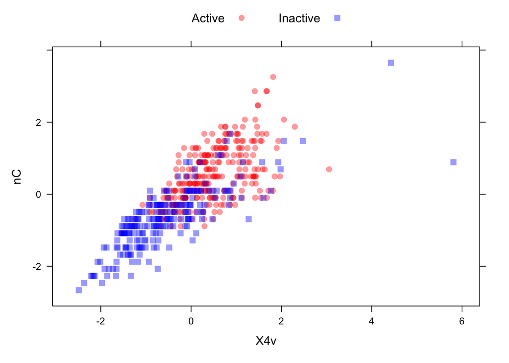

```r
transparentTheme(trans = 0.4)

plotSubset <-  data.frame(scale(mdrrDescr[, c("nC", "X4v")]))
xyplot(nC ~ X4v,
       data = plotSubset,
       groups = mdrrClass,
       auto.key = list(columns = 2))
```

Let’s do the same transforming predictors with the MPG data set:

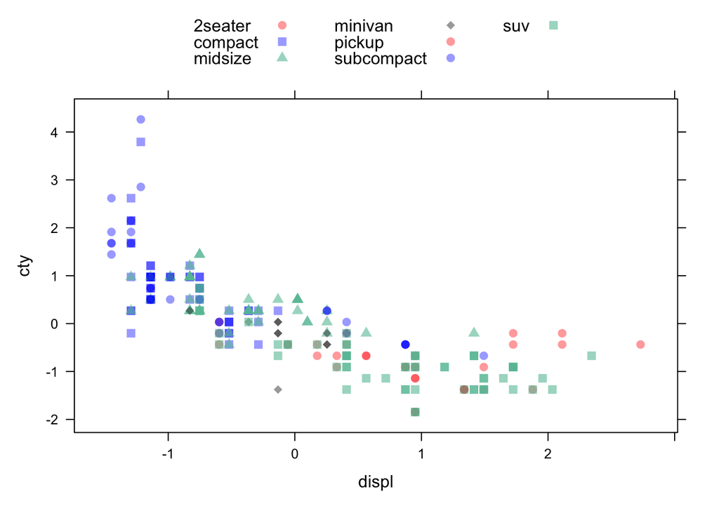

```r
class1 <- mpg$class
transparentTheme(trans = 0.4)
plotSubset1 <- data.frame(scale(mpg[,c("displ", "cty")]))
xyplot(cty~displ,
       data = plotSubset1,
       groups = class1,
       auto.key = list(columns = 3))
```

After the spatial sign:

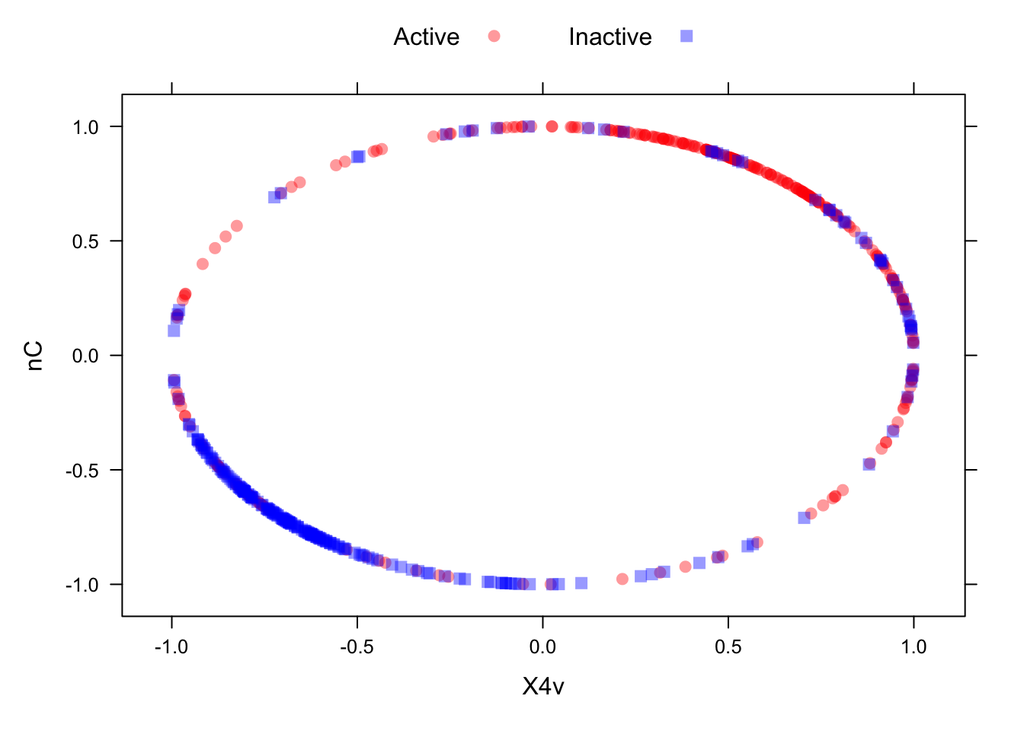

```r
transformed <- spatialSign(plotSubset)
transformed <- as.data.frame(transformed)
xyplot(nC ~ X4v,
       data = transformed,
       groups = mdrrClass,
       auto.key = list(columns = 2))
```

Perform spatial sign with the mpg data set from tidyverse:

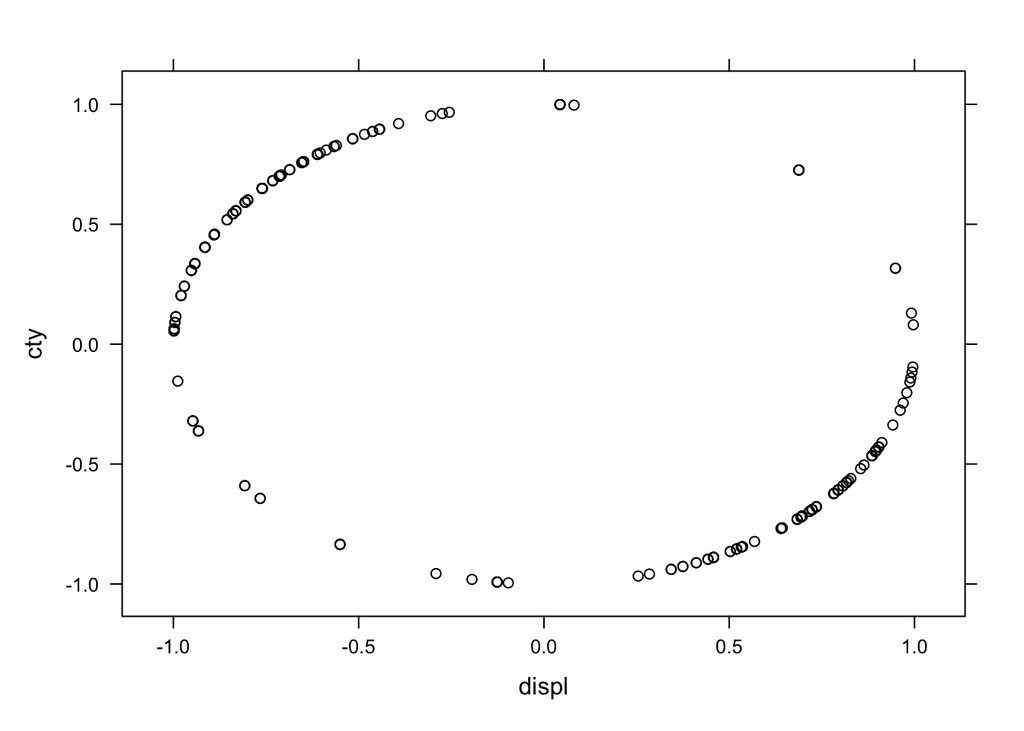

```r
transformed1 <- spatialSign(plotSubset1)
transformed1 <- as.data.frame(transformed1)
xyplot(cty ~ displ,
       data = transformed1,
       auto.key = list(columns = 2))
```

Another option, `"BoxCox"` will estimate a Box–Cox transformation on the predictors of the data are greater than zero.

```r
preProcValues2 <- preProcess(training, method = "BoxCox")
trainBC <- predict(preProcValues2, training)
testBC <- predict(preProcValues2, test)
preProcValues2
```

```
## Created from 264 samples and 31 variables
##
## Pre-processing:
##   - Box-Cox transformation (31)
##   - ignored (0)
##
## Lambda estimates for Box-Cox transformation:
##    Min. 1st Qu.  Median    Mean 3rd Qu.    Max.
## -2.0000 -0.2500  0.5000  0.4387  2.0000  2.0000
```

## 3.9 Putting It All Together

In *Applied Predictive Modeling* there is a case study where the execution times of jobs in a high performance environment are being predicted. The data are:

```r
data("schedulingData")
str(schedulingData)
```

```
## 'data.frame':    4331 obs. of  8 variables:
##  $ Protocol   : Factor w/ 14 levels "A","C","D","E",..: 4 4 4 4 4 4 4 4 4 4 ...
##  $ Compounds  : num  997 97 101 93 100 100 105 98 101 95 ...
##  $ InputFields: num  137 103 75 76 82 82 88 95 91 92 ...
##  $ Iterations : num  20 20 10 20 20 20 20 20 20 20 ...
##  $ NumPending : num  0 0 0 0 0 0 0 0 0 0 ...
##  $ Hour       : num  14 13.8 13.8 10.1 10.4 ...
##  $ Day        : Factor w/ 7 levels "Mon","Tue","Wed",..: 2 2 4 5 5 3 5 5 5 3 ...
##  $ Class      : Factor w/ 4 levels "VF","F","M","L": 2 1 1 1 1 1 1 1 1 1 ...
```

The data a mix of categorical and numerical predictors. Suppose we want to use the Yeo – Johnson transformation on the continuous predictors then center and scale them. Let’s also suppose that we will be running a tree–based model so we might want to keep the factors as factors (as opposed to creating dummy variables). We run the function on all the columns except the last, which is the outcome.

```r
pp_hpc <- preProcess(schedulingData[,-8],
                     method = c("center", "scale", "YeoJohnson"))
pp_hpc
```

```
## Created from 4331 samples and 7 variables
##
## Pre-processing:
##   - centered (5)
##   - ignored (2)
##   - scaled (5)
##   - Yeo-Johnson transformation (5)
##
## Lambda estimates for Yeo-Johnson transformation:
## -0.08, -0.03, -1.05, -1.1, 1.44
```

The two predictors labeled as “ignored”in the output are the two factor predictors. These are not altered but the numeric protectors are transformed. However, the predictor for the number of pending jobs, has a very sparse and unbalanced distribution:

```r
mean(schedulingData$NumPending == 0)
```

```
## [1] 0.7561764
```

For some other models, this might be an issue (especially if we resample or down-sample the data). We can add a filter to check for zero- or near zero-variance predictors prior to running the pre-processing calculations:

```r
pp_no_nzv <- preProcess(schedulingData[,-8],
                        method = c("center", "scale", "YeoJohnson", "nzv"))
pp_no_nzv
```

```
## Created from 4331 samples and 7 variables
##
## Pre-processing:
##   - centered (4)
##   - ignored (2)
##   - removed (1)
##   - scaled (4)
##   - Yeo-Johnson transformation (4)
##
## Lambda estimates for Yeo-Johnson transformation:
## -0.08, -0.03, -1.05, 1.44
```

Note that one predictor is labeled as “removed” and the processed data lack the sparse predictor.

## 3.10 Class Distance Calculations

`caret` contains functions to generate new predictor variables based on distances to class centroid’s (parenthesis) similar to how linear discriminate analysis works). For each level of a factor variable, the class centroid and covariance matrix is calculated. For new samples the Mahalanobis distance to each of the class centroids is computed and can be used as an additional predictor. This can be useful for nonlinear models when the true decision bottle boundary is actually linear.

In cases where there are more predictors within a class than samples, the `classDist` function has arguments called `pca` and `keep` arguments that allow for principal components analysis within each class to be used to avoid issues with singular covariance matrices.

`predict.classDist` is then used to generate the class distances. By default, the distances are logged, but this can changed by the `trans` argument to `predict.classDist`.

As an example we can use the MDRR data:

```r
centroids <- classDist(trainBC, trainMDRR)
distances <- predict(centroids, testBC)
distances <- as.data.frame(distances)
head(distances)
```

```
##                dist.Active dist.Inactive
## ACEPROMAZINE      3.787139      3.941234
## ACEPROMETAZINE    4.306137      3.992772
## MESORIDAZINE      3.707296      4.324115
## PERIMETAZINE      4.079938      4.117170
## PROPERICIAZINE    4.174101      4.430957
## DUOPERONE         4.355328      6.000025
```

This image shows a scatterplot matrix of the class distances for held-out samples:

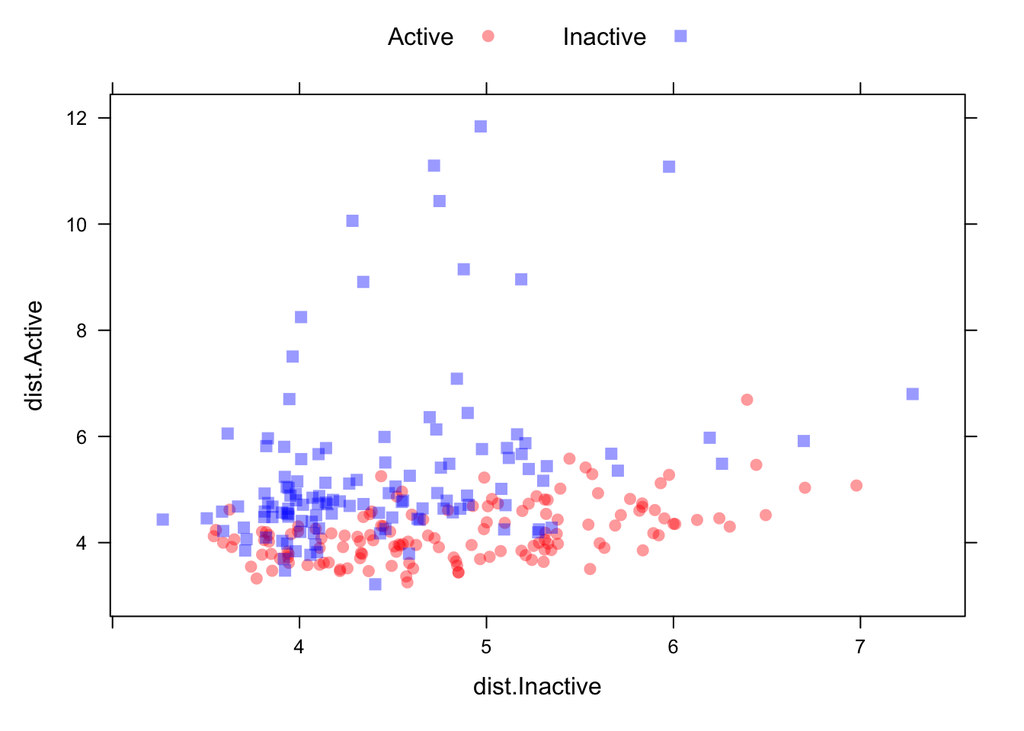

```r
xyplot(dist.Active ~ dist.Inactive,
       data = distances,
       groups = testMDRR,
       auto.key = list(columns = 2))
```